# Case 31: Summary of Data Analysis for H1 and H2

Employees Federal Credit Union (EFCU)

Author

Danielle Meza

Published

November 16, 2026

# Introduction

This report tests the two hypotheses assigned for Case 31 (n = 128 EFCU members). As in the earlier reports, I start with frequencies and means, describe the story, and then use a test to check whether the pattern is real. Test statistics appear in parentheses.

- **H1:** Members’ awareness of the regular share account will influence their opinions on how well the current financial services meet their needs.
- **H2:** Members will not be different in their opinion on the credit union’s loan rate (Q8) and the degree to which they agree that the credit union’s loan rate is lower than competitors’ (Q30).

| Hypothesis | Variables | Scale | Test | Why this test? |
| --- | --- | --- | --- | --- |
| H1 | Awareness of the regular share account (Q13r, 3 groups) and “CU meets needs of members” (Q33) | Ordinal (grouping) and interval | One-way ANOVA (Kruskal-Wallis as a check) | The outcome is a rating, and I am comparing its mean across **three** independent groups. A t-test only handles two groups. |
| H2 | Opinion on loan rates (Q8) and agreement that CU rates are lower than competitors’ (Q30) | Interval and interval | Paired-samples t-test | There is no grouping variable. The **same members** answered both questions, so each person gives a pair of scores and I test the average within-person difference. |

```r
library(tidyverse)
library(haven)
library(psych)
library(car)      # Levene's test
library(knitr)
theme_set(theme_minimal(base_size = 13))

case31 <- read_sav("Case 31 Data_efcu_1_DM_cleaned.sav") |>
  mutate(across(where(is.labelled), as.numeric))

case31 <- case31 |>
  mutate(
    # awareness of the regular share account: Unaware < Aware but not used < Aware and used
    q13r = factor(4 - q13, levels = 1:3,
                  labels = c("Unaware", "Aware but have not used", "Aware and have used"),
                  ordered = FALSE)
  )

fmt_p <- function(p) if_else(p < .001, "< .001", sprintf("%.3f", p))
pct <- function(x) round(100 * x)
```

# H1: Awareness of the Regular Share Account and Adequacy of Services

## H1 Descriptive Statistics

Q33 asks members how much they agree that the credit union meets the needs of its members (1 = Strongly Disagree, 5 = Strongly Agree). I compare it across the three awareness groups.

```r
h1_desc <- case31 |>
  group_by(`Awareness of regular share account` = q13r) |>
  summarise(n = n(), Mean = mean(q33), SD = sd(q33), Median = median(q33),
            `% Agree or strongly agree` = 100 * mean(q33 >= 4),
            `% Neutral` = 100 * mean(q33 == 3),
            `% Disagree` = 100 * mean(q33 <= 2))
kable(h1_desc, digits = 2)
```

Table 1: H1: Credit union meets members’ needs (Q33) by awareness of the regular share account

| Awareness of regular share account | n | Mean | SD | Median | % Agree or strongly agree | % Neutral | % Disagree |
| --- | --- | --- | --- | --- | --- | --- | --- |
| Unaware | 83 | 3.63 | 0.66 | 4 | 62.65 | 32.53 | 4.82 |
| Aware but have not used | 32 | 3.72 | 0.63 | 4 | 62.50 | 37.50 | 0.00 |
| Aware and have used | 13 | 3.08 | 0.76 | 3 | 30.77 | 46.15 | 23.08 |

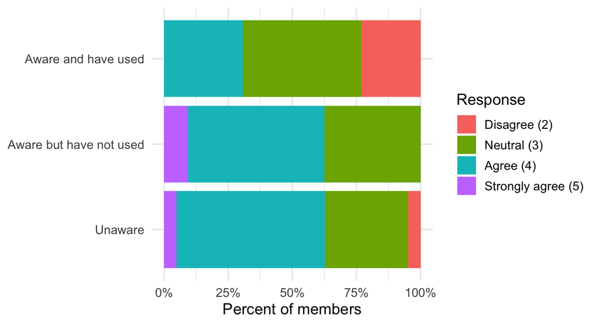

Figure 1: Responses to ‘CU meets needs of members’ (Q33) by awareness group (percent within group)

```r
case31 |>
  mutate(Response = factor(q33, 2:5, c("Disagree (2)", "Neutral (3)", "Agree (4)", "Strongly agree (5)"))) |>
  count(q13r, Response) |>
  group_by(q13r) |>
  mutate(pct = n / sum(n)) |>
  ggplot(aes(pct, q13r, fill = Response)) +
  geom_col() +
  scale_x_continuous(labels = scales::percent) +
  labs(x = "Percent of members", y = NULL)
```

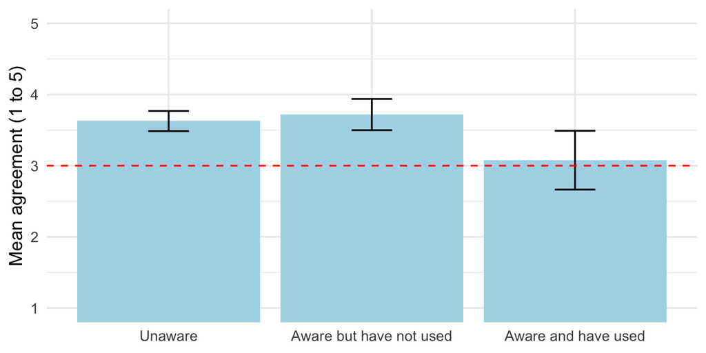

Figure 2: Mean of Q33 by awareness group, with 95% confidence intervals (dashed line = neutral 3)

```r
h1_desc |>
  mutate(se = SD / sqrt(n), group = `Awareness of regular share account`) |>
  ggplot(aes(group, Mean)) +
  geom_col(fill = "lightblue") +
  geom_errorbar(aes(ymin = Mean - 1.96 * se, ymax = Mean + 1.96 * se), width = .2) +
  geom_hline(yintercept = 3, linetype = "dashed", color = "red") +
  coord_cartesian(ylim = c(1, 5)) +
  labs(x = NULL, y = "Mean agreement (1 to 5)")
```

## H1 One-Way ANOVA

The ANOVA assumes the residuals are roughly normal and the group variances are similar. Levene’s test supports equal variances. The residuals are not perfectly normal, which is expected for a rating with only four response levels, so I confirm the result with the Kruskal-Wallis test below.

```r
h1_aov <- aov(q33 ~ q13r, data = case31)
h1_sum <- summary(h1_aov)
h1_sum
```

```
             Df Sum Sq Mean Sq F value Pr(>F)
q13r          2   4.06  2.0307   4.631 0.0115 *
Residuals   125  54.81  0.4385
---
Signif. codes:  0 '***' 0.001 '**' 0.01 '*' 0.05 '.' 0.1 ' ' 1
```

```r
leveneTest(q33 ~ q13r, data = case31)
```

```
Levene's Test for Homogeneity of Variance (center = median)
       Df F value Pr(>F)
group   2  0.0869 0.9168
      125
```

```r
shapiro.test(residuals(h1_aov))
```

```
    Shapiro-Wilk normality test

data:  residuals(h1_aov)
W = 0.87843, p-value = 7.927e-09
```

```r
h1_F  <- h1_sum[[1]][["F value"]][1]
h1_p  <- h1_sum[[1]][["Pr(>F)"]][1]
h1_df <- h1_sum[[1]][["Df"]]
h1_eta <- h1_sum[[1]][["Sum Sq"]][1] / sum(h1_sum[[1]][["Sum Sq"]])
```

## H1 Robustness Checks and Post-Hoc Comparisons

```r
# Welch's ANOVA (does not assume equal variances) and Kruskal-Wallis (does not assume normality)
oneway.test(q33 ~ q13r, data = case31)
```

```
    One-way analysis of means (not assuming equal variances)

data:  q33 and q13r
F = 3.6171, num df = 2.000, denom df = 29.729, p-value = 0.03926
```

```r
kruskal.test(q33 ~ q13r, data = case31)
```

```
    Kruskal-Wallis rank sum test

data:  q33 by q13r
Kruskal-Wallis chi-squared = 7.1098, df = 2, p-value = 0.02858
```

The overall tests say the groups differ. Tukey’s post-hoc test shows which groups are different from each other.

```r
tuk <- TukeyHSD(h1_aov)$q13r |> as.data.frame() |> rownames_to_column("Comparison")
tuk |>
  transmute(Comparison,
            `Mean difference` = diff,
            `95% CI` = sprintf("[%.2f, %.2f]", lwr, upr),
            `Adjusted p` = fmt_p(`p adj`)) |>
  kable(digits = 2)
```

Table 2: H1: Tukey post-hoc comparisons of mean Q33 between awareness groups

| Comparison | Mean difference | 95% CI | Adjusted p |
| --- | --- | --- | --- |
| Aware but have not used-Unaware | 0.09 | [-0.23, 0.42] | 0.782 |
| Aware and have used-Unaware | -0.55 | [-1.02, -0.08] | 0.017 |
| Aware and have used-Aware but have not used | -0.64 | [-1.16, -0.13] | 0.011 |

## H1 Insight

**Awareness does matter, but not in the direction you might expect. The members who actually use the regular share account are the least convinced that the credit union meets their needs.** About 63% of unaware members and 62% of members who know about the account but have not used it agree that the credit union meets members’ needs. Among members who have used it, only 31% agree (means: 3.63, 3.72, and 3.08; Table 1, Figure 1, Figure 2). The difference across the three groups is statistically significant (*F*(2, 125) = 4.63, *p* = 0.011), and the Kruskal-Wallis check agrees (*p* = 0.029). The post-hoc tests show that the “used” group differs from both other groups, while unaware members and aware-but-not-used members look alike (Table 2). Awareness explains about 7% of the variation in this rating, a modest effect.

**H1 is supported:** awareness of the regular share account is related to opinions on how well the credit union meets members’ needs.

*So what:* Simply knowing about the account does not change opinions. The difference shows up among members who have used it. One possible reason is that active users expect more from the credit union, so they judge it more critically. The “used” group is small (n = 13), so this should be treated as a lead to follow up and not a firm conclusion.

# H2: Opinion on Loan Rates and Agreement That Rates Are Lower Than Competitors’

## H2 Data Check: Putting the Two Items on the Same Scale

The two questions must run in the same direction before I can compare them in a paired test.

- **Q8** (opinion on the credit union’s loan rates) uses 1 = Very High, 2 = High, 3 = Average, 4 = Low, 5 = Very Low. A higher score means **lower** rates.
- **Q30** (the credit union’s rates are lower than competitors’) uses 1 = Strongly Disagree to 5 = Strongly Agree. A higher score means **lower** rates.

So the original Q8 and Q30 already point the same way, and I pair those two. The reversed version (Q8r, higher = higher rates) points the **opposite** way from Q30 (the two are negatively correlated, *r* = -0.49), so pairing Q8r with Q30 would compare scores on opposite scales. I report that version at the end as a check.

“No opinion” answers for Q8 are missing, so the paired test uses only members who answered both questions.

```r
h2 <- case31 |>
  filter(!is.na(q8), !is.na(q30)) |>
  mutate(diff = q8 - q30)
n_pairs <- nrow(h2)
```

## H2 Descriptive Statistics

There are **107** members with answers to both questions.

```r
h2_freq <- bind_rows(
  tibble(Item = "Q8: Opinion on loan rates",
         `1` = 100 * prop.table(table(factor(h2$q8, 1:5)))),
  tibble(Item = "Q30: CU rates lower than competitors",
         `1` = 100 * prop.table(table(factor(h2$q30, 1:5))))
) |>
  mutate(level = rep(1:5, 2)) |>
  pivot_wider(names_from = level, values_from = `1`) |>
  mutate(`% 4 or 5` = `4` + `5`, `% 1 or 2` = `1` + `2`)
kable(h2_freq, digits = 1)
```

Table 3: H2: Percent of members at each response level (both items scored so that higher = lower rates)

| Item | 1 | 2 | 3 | 4 | 5 | % 4 or 5 | % 1 or 2 |
| --- | --- | --- | --- | --- | --- | --- | --- |
| Q8: Opinion on loan rates | 3.738318 | 24.29907 | 55.14019 | 15.88785 | 0.9345794 | 16.82243 | 28.03738 |
| Q30: CU rates lower than competitors | 3.738318 | 23.36449 | 41.12150 | 27.10280 | 4.6728972 | 31.77570 | 27.10280 |

```r
h2_desc <- describe(h2[, c("q8", "q30", "diff")])[, c("n", "mean", "sd", "median", "min", "max")]
rownames(h2_desc) <- c("Q8: Opinion on loan rates (higher = lower rates)",
                       "Q30: CU rates lower than competitors", "Difference (Q8 minus Q30)")
kable(h2_desc, digits = 2)
```

Table 4: H2: Descriptive statistics for the paired items and the within-person difference

|  | n | mean | sd | median | min | max |
| --- | --- | --- | --- | --- | --- | --- |
| Q8: Opinion on loan rates (higher = lower rates) | 107 | 2.86 | 0.76 | 3 | 1 | 5 |
| Q30: CU rates lower than competitors | 107 | 3.06 | 0.92 | 3 | 1 | 5 |
| Difference (Q8 minus Q30) | 107 | -0.20 | 0.86 | 0 | -3 | 3 |

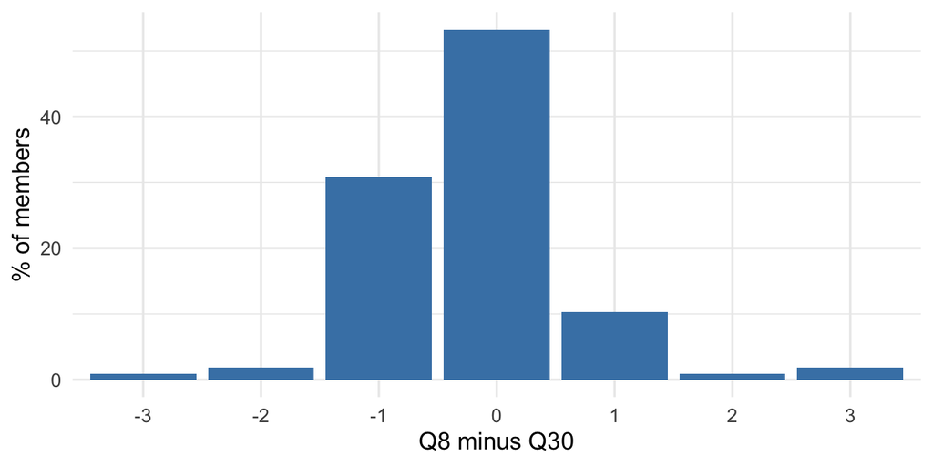

Figure 3: Within-person difference between Q8 and Q30 (0 = same answer on both questions)

```r
h2 |>
  count(diff) |>
  mutate(pct = 100 * n / sum(n)) |>
  ggplot(aes(factor(diff), pct)) +
  geom_col(fill = "steelblue") +
  labs(x = "Q8 minus Q30", y = "% of members")
```

```r
same <- mean(h2$diff == 0)
within1 <- mean(abs(h2$diff) <= 1)
h2_t <- t.test(h2$q8, h2$q30, paired = TRUE)
h2_w <- wilcox.test(h2$q8, h2$q30, paired = TRUE, exact = FALSE)
```

## H2 Paired-Samples t-Test

```r
h2_t
```

```
    Paired t-test

data:  h2$q8 and h2$q30
t = -2.3534, df = 106, p-value = 0.02045
alternative hypothesis: true mean difference is not equal to 0
95 percent confidence interval:
 -0.36159829 -0.03092508
sample estimates:
mean difference
     -0.1962617
```

```r
h2_w
```

```
    Wilcoxon signed rank test with continuity correction

data:  h2$q8 and h2$q30
V = 391.5, p-value = 0.009485
alternative hypothesis: true location shift is not equal to 0
```

As a check on the scale direction, here is what happens if Q8r (higher = higher rates) is paired with Q30 without reversing either one.

```r
h2_lit <- t.test(h2$q8r, h2$q30, paired = TRUE)
h2_lit
```

```
    Paired t-test

data:  h2$q8r and h2$q30
t = 0.60088, df = 106, p-value = 0.5492
alternative hypothesis: true mean difference is not equal to 0
95 percent confidence interval:
 -0.1934139  0.3616382
sample estimates:
mean difference
     0.08411215
```

That version shows a mean difference of 0.08 (*p* = 0.55), but it compares two scores that run in opposite directions, so the result says little about whether members’ views match.

## H2 Insight

**Members’ views on the loan rate and on whether the rate beats competitors’ are close but not identical.** About 53% of members gave the same score on both questions and 94% were within one point (Figure 3). Typical members see the rate as roughly average (mean 2.86, or 17% who call it low or very low) and are about neutral on whether it beats competitors (mean 3.06, or 32% agreeing; Table 3, Table 4). Members are slightly more willing to agree that the credit union’s rates are lower than competitors’ than to call the rates low in their own right. The gap is small (about 0.2 of a scale point) but statistically significant (*t*(106) = -2.35, *p* = 0.02; the Wilcoxon signed-rank check agrees, *p* = 0.009).

**H2 is not strictly supported:** there is a small difference between the two views. It is a small gap in practical terms, since neither opinion is strongly favorable or unfavorable.

*So what:* Members do not see the credit union’s loan rates as a clear advantage. The message that the credit union’s rates beat competitors’ lands a bit better than the plain claim that its rates are low, but neither is a strong selling point.

# Summary of Insights

[output not shown]

## Notes and Limits

- The “aware and have used” group for H1 has only 13 members, so that comparison is less stable.
- Q8 had 21 “no opinion” answers, so H2 uses 107 of the 128 members.
- The 1-to-5 items are treated as interval. I used non-parametric checks (Kruskal-Wallis and Wilcoxon) to confirm both results.

# Appendix

- **GitHub Repo:** https://github.com/dmcpp26/ibm6500-assignments
- **GitHub Pages:** https://dmcpp26.github.io/ibm6500-assignments/IC-Case31-H1-H2/summary-h1-h2-case31-dmeza.html